# riboprof_analysis_d5[20231005]

Load all the required packages:

```r
library(tidyr)
library(dplyr)
library(stringr)
library(ggplot2)
library(riboWaltz)
library(data.table)
library(limma)
library(edgeR)
```

This notebook processes .bam files generated using STAR alignment against primary human GRCh38 GENCODE annotation. .bam files used are in ./data/Try3 processed files used are in ./data/hiND5

```r
# File contains gene counts for each transcript (rows) in each sample (columns)
combined_f <- './data/hiND5/combined_file.txt'
counts = read.table(combined_f, sep='\t', header=TRUE, row.names=1)
colnames(counts) =c('wt_rep1_RFP',
                    'wt_rep2_RFP',
                    'wt_rep3_RFP',
                    'Nterm_rep1_RFP',
                    'Nterm_rep2_RFP',
                    'Nterm_rep3_RFP',
                    'wt_rep1_RNA',
                    'Nterm_rep2_RNA',
                    'wt_rep2_RNA',
                    'wt_rep3_RNA',
                    'Nterm_rep1_RNA',
                    'Nterm_rep3_RNA')
head(counts)
```

|  | wt_rep1_RFP | wt_rep2_RFP | wt_rep3_RFP | Nterm_rep1_RFP | Nterm_rep2_RFP | Nterm_rep3_RFP | wt_rep1_RNA | Nterm_rep2_RNA | wt_rep2_RNA | wt_rep3_RNA | Nterm_rep1_RNA | Nterm_rep3_RNA |
| --- | --- | --- | --- | --- | --- | --- | --- | --- | --- | --- | --- | --- |
| ENST00000258538 | 52 | 75 | 79 | 58 | 72 | 158 | 65 | 40 | 53 | 26 | 46 | 54 |
| ENST00000313213 | 0 | 0 | 0 | 1 | 1 | 2 | 3 | 0 | 1 | 3 | 1 | 2 |
| ENST00000534061 | 22 | 20 | 30 | 24 | 15 | 41 | 35 | 33 | 57 | 31 | 42 | 45 |
| ENST00000437198 | 207 | 256 | 312 | 267 | 287 | 649 | 293 | 224 | 287 | 211 | 305 | 259 |
| ENST00000564996 | 31 | 54 | 73 | 80 | 71 | 136 | 212 | 163 | 243 | 159 | 232 | 202 |
| ENST00000288098 | 1 | 1 | 1 | 2 | 2 | 2 | 7 | 2 | 5 | 11 | 7 | 2 |

```r
# convert to gene names
mart_path = './index/mart_homo-sapiens_geneID_transcriptID_transcriptID-v_gene-name.txt'
mart = read.table(mart_path, sep='\t', header=TRUE)
rownames(mart) = mart$Transcript.stable.ID

mart[1:10,]
```

|  | Gene.stable.ID | Transcript.stable.ID | Transcript.stable.ID.version | Gene.name |
| --- | --- | --- | --- | --- |
| ENST00000387314 | ENSG00000210049 | ENST00000387314 | ENST00000387314.1 | MT-TF |
| ENST00000389680 | ENSG00000211459 | ENST00000389680 | ENST00000389680.2 | MT-RNR1 |
| ENST00000387342 | ENSG00000210077 | ENST00000387342 | ENST00000387342.1 | MT-TV |
| ENST00000387347 | ENSG00000210082 | ENST00000387347 | ENST00000387347.2 | MT-RNR2 |
| ENST00000386347 | ENSG00000209082 | ENST00000386347 | ENST00000386347.1 | MT-TL1 |
| ENST00000361390 | ENSG00000198888 | ENST00000361390 | ENST00000361390.2 | MT-ND1 |
| ENST00000387365 | ENSG00000210100 | ENST00000387365 | ENST00000387365.1 | MT-TI |
| ENST00000387372 | ENSG00000210107 | ENST00000387372 | ENST00000387372.1 | MT-TQ |
| ENST00000387377 | ENSG00000210112 | ENST00000387377 | ENST00000387377.1 | MT-TM |
| ENST00000361453 | ENSG00000198763 | ENST00000361453 | ENST00000361453.3 | MT-ND2 |

```r
name_for_tid = mart[,"Gene.name"]
names(name_for_tid) = rownames(mart)
rownames(counts) = paste(name_for_tid[rownames(counts)], rownames(counts), sep='_')
counts[1:10,]
```

|  | wt_rep1_RFP | wt_rep2_RFP | wt_rep3_RFP | Nterm_rep1_RFP | Nterm_rep2_RFP | Nterm_rep3_RFP | wt_rep1_RNA | Nterm_rep2_RNA | wt_rep2_RNA | wt_rep3_RNA | Nterm_rep1_RNA | Nterm_rep3_RNA |
| --- | --- | --- | --- | --- | --- | --- | --- | --- | --- | --- | --- | --- |
| SLC41A2_ENST00000258538 | 52 | 75 | 79 | 58 | 72 | 158 | 65 | 40 | 53 | 26 | 46 | 54 |
| PFN4_ENST00000313213 | 0 | 0 | 0 | 1 | 1 | 2 | 3 | 0 | 1 | 3 | 1 | 2 |
| NAALAD2_ENST00000534061 | 22 | 20 | 30 | 24 | 15 | 41 | 35 | 33 | 57 | 31 | 42 | 45 |
| PARN_ENST00000437198 | 207 | 256 | 312 | 267 | 287 | 649 | 293 | 224 | 287 | 211 | 305 | 259 |
| KLHL36_ENST00000564996 | 31 | 54 | 73 | 80 | 71 | 136 | 212 | 163 | 243 | 159 | 232 | 202 |
| IL34_ENST00000288098 | 1 | 1 | 1 | 2 | 2 | 2 | 7 | 2 | 5 | 11 | 7 | 2 |
| OR5H15_ENST00000641450 | 0 | 0 | 0 | 0 | 0 | 0 | 0 | 0 | 0 | 0 | 0 | 1 |
| RELT_ENST00000064780 | 30 | 53 | 51 | 52 | 48 | 96 | 74 | 68 | 82 | 48 | 89 | 52 |
| TSTD2_ENST00000341170 | 259 | 387 | 505 | 444 | 498 | 894 | 475 | 356 | 470 | 342 | 464 | 449 |
| _ENST00000380361 | 0 | 0 | 0 | 1 | 2 | 1 | 549 | 438 | 544 | 405 | 530 | 505 |

```r
dim(counts)
```

```
[1] 19972    12
```

```r
# option to exclude mitochondria-encoded genes, also genes without gene names

counts = counts[-grep('^MT-*', rownames(counts)),]
counts = counts[grep('.+_', rownames(counts)),]

dim(counts)
```

```
[1] 19280    12
```

```r
counts[1:10,]
```

|  | wt_rep1_RFP | wt_rep2_RFP | wt_rep3_RFP | Nterm_rep1_RFP | Nterm_rep2_RFP | Nterm_rep3_RFP | wt_rep1_RNA | Nterm_rep2_RNA | wt_rep2_RNA | wt_rep3_RNA | Nterm_rep1_RNA | Nterm_rep3_RNA |
| --- | --- | --- | --- | --- | --- | --- | --- | --- | --- | --- | --- | --- |
| SLC41A2_ENST00000258538 | 52 | 75 | 79 | 58 | 72 | 158 | 65 | 40 | 53 | 26 | 46 | 54 |
| PFN4_ENST00000313213 | 0 | 0 | 0 | 1 | 1 | 2 | 3 | 0 | 1 | 3 | 1 | 2 |
| NAALAD2_ENST00000534061 | 22 | 20 | 30 | 24 | 15 | 41 | 35 | 33 | 57 | 31 | 42 | 45 |
| PARN_ENST00000437198 | 207 | 256 | 312 | 267 | 287 | 649 | 293 | 224 | 287 | 211 | 305 | 259 |
| KLHL36_ENST00000564996 | 31 | 54 | 73 | 80 | 71 | 136 | 212 | 163 | 243 | 159 | 232 | 202 |
| IL34_ENST00000288098 | 1 | 1 | 1 | 2 | 2 | 2 | 7 | 2 | 5 | 11 | 7 | 2 |
| OR5H15_ENST00000641450 | 0 | 0 | 0 | 0 | 0 | 0 | 0 | 0 | 0 | 0 | 0 | 1 |
| RELT_ENST00000064780 | 30 | 53 | 51 | 52 | 48 | 96 | 74 | 68 | 82 | 48 | 89 | 52 |
| TSTD2_ENST00000341170 | 259 | 387 | 505 | 444 | 498 | 894 | 475 | 356 | 470 | 342 | 464 | 449 |
| UMAD1_ENST00000682710 | 34 | 45 | 54 | 52 | 56 | 104 | 86 | 75 | 96 | 56 | 71 | 43 |

```r
# parse and assemble sample data

samples = array(data=NA, dim=c(ncol(counts), 3))
rownames(samples) = colnames(counts)
colnames(samples) = c('genotype', 'rep', 'RFP_or_RNA')

splits = strsplit(colnames(counts), '_')
for (i in 1:nrow(samples)) {
   samples[i,] = splits[[i]][1:3]
}

samples = data.frame(samples)

samples$RFP_or_RNA = factor(samples$RFP_or_RNA, levels=c('RFP', 'RNA'))
samples$genotype = factor(samples$genotype)
samples$rep = factor(substr(samples$rep, 4, 4), levels = c(1, 2, 3))
samples$grouping = paste(samples$genotype, samples$RFP_or_RNA, sep='_')

samples
```

|  | genotype | rep | RFP_or_RNA | grouping |
| --- | --- | --- | --- | --- |
| wt_rep1_RFP | wt | 1 | RFP | wt_RFP |
| wt_rep2_RFP | wt | 2 | RFP | wt_RFP |
| wt_rep3_RFP | wt | 3 | RFP | wt_RFP |
| Nterm_rep1_RFP | Nterm | 1 | RFP | Nterm_RFP |
| Nterm_rep2_RFP | Nterm | 2 | RFP | Nterm_RFP |
| Nterm_rep3_RFP | Nterm | 3 | RFP | Nterm_RFP |
| wt_rep1_RNA | wt | 1 | RNA | wt_RNA |
| Nterm_rep2_RNA | Nterm | 2 | RNA | Nterm_RNA |
| wt_rep2_RNA | wt | 2 | RNA | wt_RNA |
| wt_rep3_RNA | wt | 3 | RNA | wt_RNA |

[output cut: 2 more lines]

### analysis for RNA with all 6 samples

```r
# first analyze only the RNA samples on their own

counts_rna = counts[,samples$RFP_or_RNA=='RNA']
samples_rna = samples[samples$RFP_or_RNA=='RNA',]
group_rna = samples_rna$grouping

data_rna = DGEList(counts = counts_rna, samples = samples_rna, group = group_rna)
```

```r
# filter out low-expressed genes
# try min.count = 10 (gene has to be expressed above 10 counts in a 'meaningful' number of samples)
# ^^ min.count = 10 is actually the default, I believe

# I think 'meaningful' is defined by the group attribute of data_rna

# the edgeR User's Guide mentions this should be performed on normalized counts,
# but in all the examples it's done before TMM normalization...

# going to generate a cpm version of data_rna and use that for determining which genes to keep.

data_rna_cpm <- cpm(data_rna, log=FALSE)

# generate the vector for which genes to keep

# if you don't want to use the filterByExpr function, can write your own
# criteria for which genes to keep

keep_cpm = filterByExpr(data_rna_cpm, min.count=10, group = data_rna$samples$group)
table(keep_cpm)
```

```
keep_cpm
FALSE  TRUE
 9970  9310
```

```r
# plot CPM histograms to compare raw vs. filtered data

L <- mean(data_rna$samples$lib.size) * 1e-6
M <- median(data_rna$samples$lib.size) * 1e-6

lcpm.cutoff <- log2(10/M + 2/L)
library(RColorBrewer)
nsamples <- ncol(data_rna)
col <- brewer.pal(nsamples, "Paired")
par(mfrow=c(1,2))

lcpm <- cpm(data_rna, log=TRUE)

plot(density(lcpm[,1]), col=col[1], lwd=2, ylim=c(0,0.26), las=2, main="", xlab="")
title(main="A. Raw RNA data", xlab="Log-cpm")
```

```r
abline(v=lcpm.cutoff, lty=3)
for (i in 2:nsamples){
    den <- density(lcpm[,i])
    lines(den$x, den$y, col=col[i], lwd=2)
}
```

```r
legend("topright", rownames(data_rna$samples), text.col=col, bty="n")


# here is where I actually filter out the low-expressed genes from data_rna
data_rna = data_rna[keep_cpm, keep.lib.sizes=FALSE]

lcpm <- cpm(data_rna, log=TRUE)

plot(density(lcpm[,1]), col=col[1], lwd=2, ylim=c(0,0.26), las=2, main="", xlab="")
```

```r
title(main="B. Filtered RNA data", xlab="Log-cpm")
abline(v=lcpm.cutoff, lty=3)
```

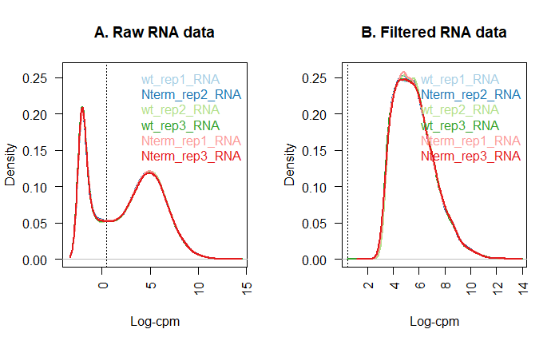

```r
for (i in 2:nsamples){
    den <- density(lcpm[,i])
    lines(den$x, den$y, col=col[i], lwd=2)
}
legend("topright", rownames(data_rna$samples), text.col=col, bty="n")
```

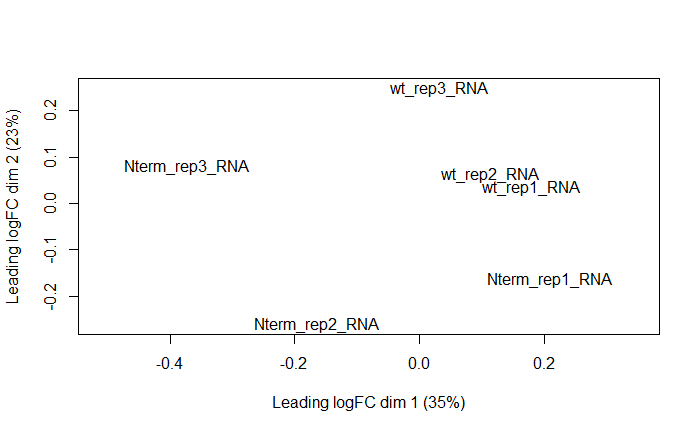

```r
# calculate normalizing factors for RNA samples

data_rna = calcNormFactors(data_rna, method='TMM')

# plot multidimensional scaling -- an unsupervised look at the biggest
# differences between samples

lcpm = cpm(data_rna, log=TRUE)
plotMDS(lcpm, labels=rownames(data_rna$samples))
```

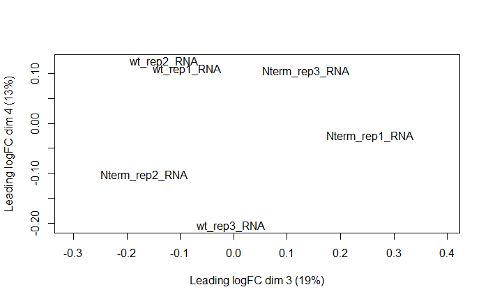

```r
plotMDS(lcpm, labels=rownames(data_rna$samples), dim.plot=c(3,4))
```

```r
data_rna$samples
```

|  | group | lib.size | norm.factors | genotype | rep | RFP_or_RNA | grouping |
| --- | --- | --- | --- | --- | --- | --- | --- |
| wt_rep1_RNA | wt_RNA | 9851416 | 0.9993923 | wt | 1 | RNA | wt_RNA |
| Nterm_rep2_RNA | Nterm_RNA | 7196846 | 0.9925433 | Nterm | 2 | RNA | Nterm_RNA |
| wt_rep2_RNA | wt_RNA | 9109705 | 1.0155249 | wt | 2 | RNA | wt_RNA |
| wt_rep3_RNA | wt_RNA | 6972546 | 0.9917424 | wt | 3 | RNA | wt_RNA |
| Nterm_rep1_RNA | Nterm_RNA | 9522288 | 1.0004465 | Nterm | 1 | RNA | Nterm_RNA |
| Nterm_rep3_RNA | Nterm_RNA | 7740225 | 1.0005325 | Nterm | 3 | RNA | Nterm_RNA |

```r
line = data_rna$samples$genotype

# this design matrix is fairly simple. we intend to compare by 'line', and lane' is included as batch variable
design_rna = model.matrix(~0+line, data=data_rna$samples)
colnames(design_rna) = gsub('>', '_to_', colnames(design_rna))

design_rna
```

```
               lineNterm linewt
wt_rep1_RNA            0      1
Nterm_rep2_RNA         1      0
wt_rep2_RNA            0      1
wt_rep3_RNA            0      1
Nterm_rep1_RNA         1      0
Nterm_rep3_RNA         1      0
attr(,"assign")
[1] 1 1
attr(,"contrasts")
attr(,"contrasts")$line
[1] "contr.treatment"
```

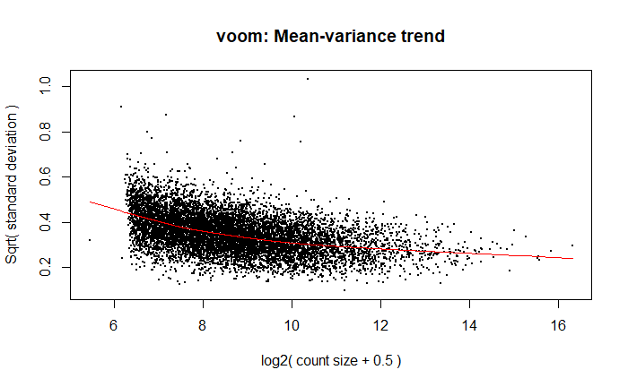

```r
# make contrasts

rna_de = makeContrasts(lineNterm-linewt,
                       levels=colnames(design_rna))

# perform voom

v_rna = voom(data_rna, design_rna, plot=TRUE)
```

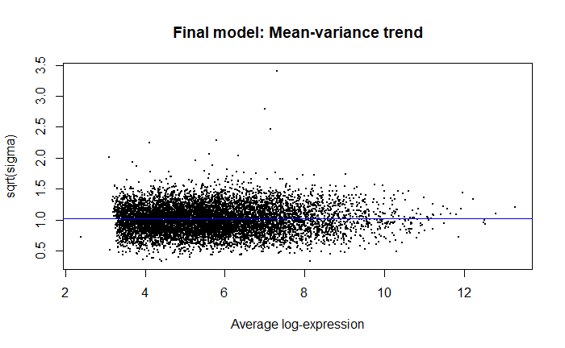

```r
# run the linear model

v_rna_fit = lmFit(v_rna, design_rna)
v_rna_fit = contrasts.fit(v_rna_fit, contrasts=rna_de)
e_rna_fit = eBayes(v_rna_fit)
plotSA(e_rna_fit, main='Final model: Mean-variance trend')
```

```r
# test for any significantly diff expr genes

dt_rna = decideTests(e_rna_fit, p.value=0.1)
summary(dt_rna)
```

```
       lineNterm - linewt
Down                    9
NotSig               9293
Up                      8
```

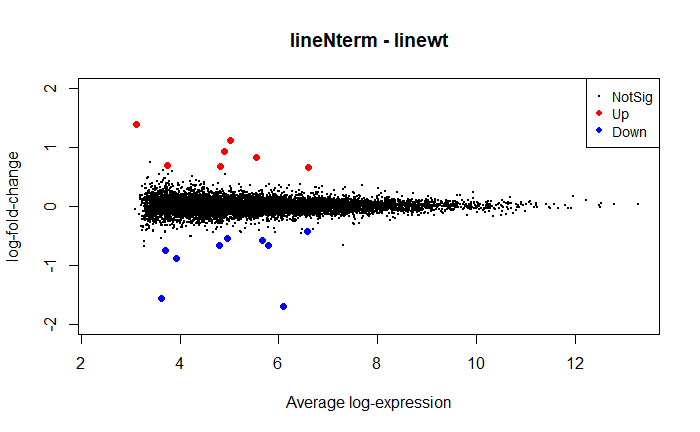

```r
# plots for mean expr vs logFC

plotMD(e_rna_fit,
       column=1,
       status=dt_rna[,1],
       main=colnames(e_rna_fit)[1],
       ylim=c(-2,2))
```

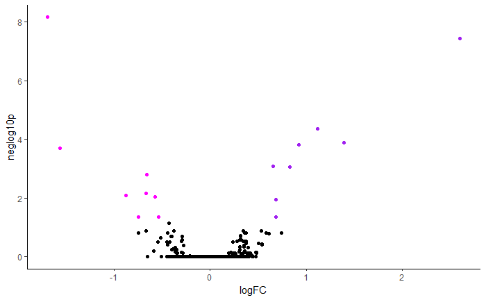

```r
# generate a table of all kept genes as ranked by p-value
ranked_genes = topTable(e_rna_fit, coef=1, number=sum(keep_cpm), sort.by='p')

# volcano plot
ranked_genes$neglog10p = -log(ranked_genes$adj.P.Val, 10)
ranked_genes$plot_fill = rep('black', nrow(ranked_genes))
ranked_genes[ranked_genes$logFC > 0.25 & ranked_genes$adj.P.Val < 0.05,'plot_fill'] = 'purple'
ranked_genes[ranked_genes$logFC < -0.25 & ranked_genes$adj.P.Val < 0.05,'plot_fill'] = 'magenta'

pal = c('black', 'magenta', 'purple')

ranked_genes$plot_fill = factor(ranked_genes$plot_fill, levels = pal)

options(repr.plot.width=4, repr.plot.height=4)

ggplot(data=ranked_genes, aes(x=logFC, y=neglog10p, color=plot_fill)) +
  geom_point() +
  scale_color_manual(values=pal) +
  theme_classic() +
  theme(legend.position='none')
```

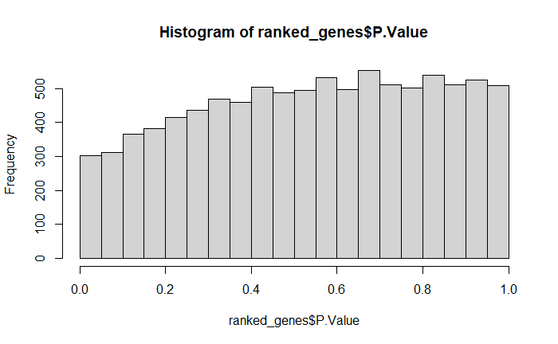

```r
# check distribution of p-values
hist(ranked_genes$P.Value)
```

### analysis for RFP w/ all 6 samples

```r
# only the RPF samples on their own

counts_rfp = counts[,samples$RFP_or_RNA=='RFP']
samples_rfp = samples[samples$RFP_or_RNA=='RFP',]
group_rfp = samples_rfp$grouping

data_rfp = DGEList(counts = counts_rfp, samples = samples_rfp, group = group_rfp)

# filter out low-expressed genes
# try min.count = 10 (gene has to be expressed above 10 counts in a 'meaningful' number of samples)
# ^^ min.count = 10 is actually the default, I believe

# I think 'meaningful' is defined by the group attribute of data_rna

# the edgeR User's Guide mentions this should be performed on normalized counts,
# but in all the examples it's done before TMM normalization...

# going to generate a cpm version of data_rna and use that for determining which genes to keep.

data_rfp_cpm <- cpm(data_rfp, log=FALSE)
head(data_rfp_cpm)
```

```
                        wt_rep1_RFP wt_rep2_RFP wt_rep3_RFP Nterm_rep1_RFP Nterm_rep2_RFP Nterm_rep3_RFP
SLC41A2_ENST00000258538  13.3825502  14.0917368  11.8030010      9.6758151     11.2953402     13.9493619
PFN4_ENST00000313213      0.0000000   0.0000000   0.0000000      0.1668244      0.1568797      0.1765742
NAALAD2_ENST00000534061   5.6618482   3.7577965   4.4821523      4.0037856      2.3531959      3.6197711
PARN_ENST00000437198     53.2728442  48.0997950  46.6143839     44.5421146     45.0244811     57.2983282
KLHL36_ENST00000564996    7.9780588  10.1460505  10.9065706     13.3459519     11.1384605     12.0070457
IL34_ENST00000288098      0.2573567   0.1878898   0.1494051      0.3336488      0.3137595      0.1765742
```

```r
# generate the vector for which genes to keep

# if you don't want to use the filterByExpr function, can write your own
# criteria for which genes to keep

keep_cpm = filterByExpr(data_rfp_cpm, min.count=10, group = data_rfp$samples$group)
table(keep_cpm)
```

```
keep_cpm
FALSE  TRUE
 9915  9365
```

```r
# plot CPM histograms to compare raw vs. filtered data

L <- mean(data_rfp$samples$lib.size) * 1e-6
M <- median(data_rfp$samples$lib.size) * 1e-6

lcpm.cutoff <- log2(10/M + 2/L)
library(RColorBrewer)
nsamples <- ncol(data_rfp)
col <- brewer.pal(nsamples, "Paired")
par(mfrow=c(1,2))

lcpm <- cpm(data_rfp, log=TRUE)

plot(density(lcpm[,1]), col=col[1], lwd=2, ylim=c(0,0.26), las=2, main="", xlab="")
title(main="A. Raw RFP data", xlab="Log-cpm")
```

```r
abline(v=lcpm.cutoff, lty=3)
for (i in 2:nsamples){
    den <- density(lcpm[,i])
    lines(den$x, den$y, col=col[i], lwd=2)
}
```

```r
legend("topright", rownames(data_rfp$samples), text.col=col, bty="n")


# here is where I actually filter out the low-expressed genes from data_rfp
data_rfp = data_rfp[keep_cpm, keep.lib.sizes=FALSE]

lcpm <- cpm(data_rfp, log=TRUE)

plot(density(lcpm[,1]), col=col[1], lwd=2, ylim=c(0,0.26), las=2, main="", xlab="")
```

```r
title(main="B. Filtered RFP data", xlab="Log-cpm")
abline(v=lcpm.cutoff, lty=3)
```

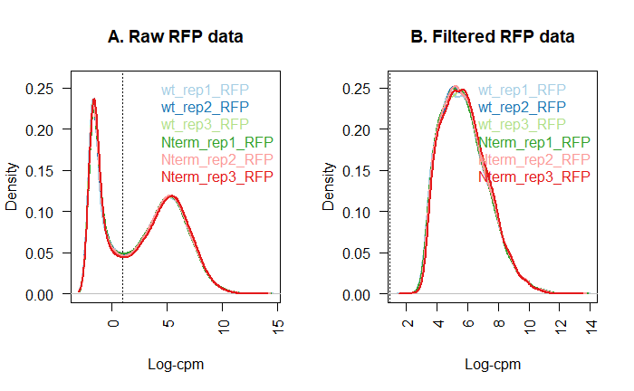

```r
for (i in 2:nsamples){
    den <- density(lcpm[,i])
    lines(den$x, den$y, col=col[i], lwd=2)
}
legend("topright", rownames(data_rfp$samples), text.col=col, bty="n")
```

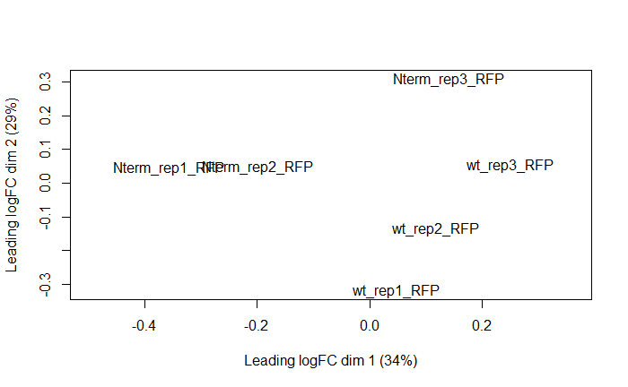

```r
# calculate normalizing factors for RNA samples

data_rfp = calcNormFactors(data_rfp, method='TMM')

# plot multidimensional scaling -- an unsupervised look at the biggest
# differences between samples

lcpm = cpm(data_rfp, log=TRUE)
plotMDS(lcpm, labels=rownames(data_rfp$samples))
```

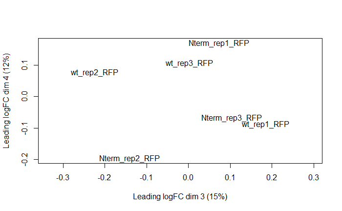

```r
plotMDS(lcpm, labels=rownames(data_rfp$samples), dim.plot=c(3,4))
```

```r
line = data_rfp$samples$genotype

# this design matrix is fairly simple. we intend to compare by 'line', and lane' is included as batch variable
design_rfp = model.matrix(~0+line, data=data_rfp$samples)
colnames(design_rfp) = gsub('>', '_to_', colnames(design_rfp))

design_rfp
```

```
               lineNterm linewt
wt_rep1_RFP            0      1
wt_rep2_RFP            0      1
wt_rep3_RFP            0      1
Nterm_rep1_RFP         1      0
Nterm_rep2_RFP         1      0
Nterm_rep3_RFP         1      0
attr(,"assign")
[1] 1 1
attr(,"contrasts")
attr(,"contrasts")$line
[1] "contr.treatment"
```

```r
# make contrasts

rfp_de = makeContrasts(lineNterm-linewt,
                       levels=colnames(design_rfp))

rfp_de
```

```
           Contrasts
Levels      lineNterm - linewt
  lineNterm                  1
  linewt                    -1
```

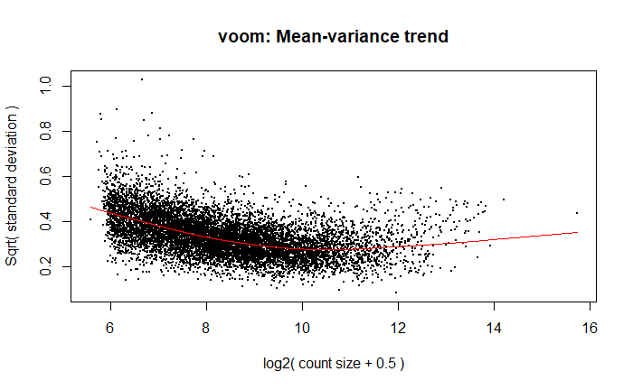

```r
# perform voom

v_rfp = voom(data_rfp, design_rfp, plot=TRUE)
```

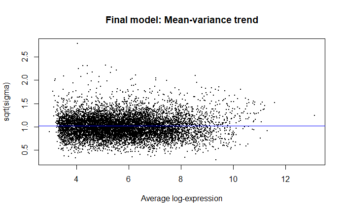

```r
# run the linear model

v_rfp_fit = lmFit(v_rfp, design_rfp)
v_rfp_fit = contrasts.fit(v_rfp_fit, contrasts=rfp_de)
e_rfp_fit = eBayes(v_rfp_fit)
plotSA(e_rfp_fit, main='Final model: Mean-variance trend')
```

```r
# test for any significantly diff expr genes

dt_rfp = decideTests(e_rfp_fit, adjust.method = 'BH', p.value=0.1)
summary(dt_rfp)
```

```
       lineNterm - linewt
Down                   16
NotSig               9332
Up                     17
```

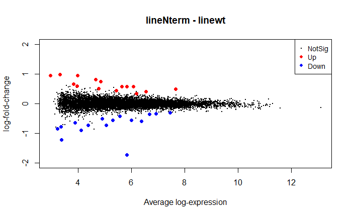

```r
# plots for mean expr vs logFC

plotMD(e_rfp_fit,
       column=1,
       status=dt_rfp[,1],
       main=colnames(e_rfp_fit)[1],
       ylim=c(-2,2))
```

```r
# generate a table of all kept genes as ranked by p-value
ranked_genes_rfp = topTable(e_rfp_fit, coef=1, number=sum(keep_cpm), sort.by='p')
```

### analyze differential TE for all 6 samples

```r
# create a DGE data object for all RNA and RPF samples

data_all = DGEList(counts = counts, samples = samples, group = samples$grouping)

# filter out low-expressed genes

# when calculating TE, Gerald filters by genes that are expressed at CPM > 1 in at least a min
# number of RPF libraries, b/c his RPF libraries have fewer reads...my RPF and RNA libraries are
# pretty similar in size...

# try min.count = 10 (gene has to be expressed above 10 counts in a 'meaningful' number of samples)
# ^^ min.count = 10 is actually the default, I believe

# I think 'meaningful' is defined by the group attribute of data_rna

# the edgeR User's Guide mentions this should be performed on normalized counts,
# but in all the examples it's done before TMM normalization...

# going to generate a cpm version of data_rna and use that for determining which genes to keep.

data_all_cpm <- cpm(data_all, log=FALSE)

# generate the vector for which genes to keep

keep_all_cpm = filterByExpr(data_all_cpm, min.count=10, data_all$samples$group)
table(keep_all_cpm)
```

```
keep_all_cpm
FALSE  TRUE
 9374  9906
```

```r
# plot CPM histograms to compare raw vs. filtered data

L <- mean(data_all$samples$lib.size) * 1e-6
M <- median(data_all$samples$lib.size) * 1e-6

lcpm.cutoff <- log2(10/M + 2/L)
library(RColorBrewer)
nsamples <- ncol(data_all)
col <- brewer.pal(nsamples, "Paired")
par(mfrow=c(1,2))

lcpm <- cpm(data_all, log=TRUE)

plot(density(lcpm[,1]), col=col[1], lwd=2, ylim=c(0,0.26), las=2, main="", xlab="")
title(main="A. Raw RNA and RPF data", xlab="Log-cpm")
```

```r
abline(v=lcpm.cutoff, lty=3)
for (i in 2:nsamples){
    den <- density(lcpm[,i])
    lines(den$x, den$y, col=col[i], lwd=2)
}
```

```r
legend("topright", rownames(data_all$samples), text.col=col, bty="n")


# here is where I actually filter out the low-expressed genes from data_all
data_all = data_all[keep_all_cpm, keep.lib.sizes=FALSE]

lcpm <- cpm(data_all, log=TRUE)

plot(density(lcpm[,1]), col=col[1], lwd=2, ylim=c(0,0.26), las=2, main="", xlab="")
```

```r
title(main="B. Filtered RNA and RPF data", xlab="Log-cpm")
abline(v=lcpm.cutoff, lty=3)
```

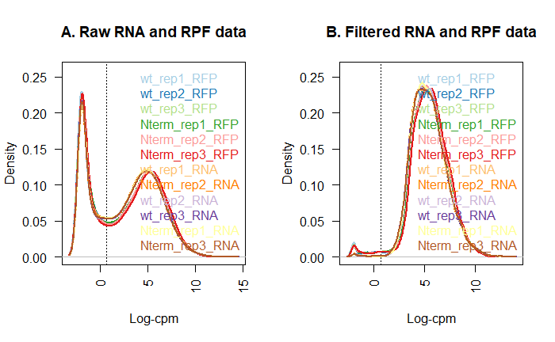

```r
for (i in 2:nsamples){
    den <- density(lcpm[,i])
    lines(den$x, den$y, col=col[i], lwd=2)
}
legend("topright", rownames(data_all$samples), text.col=col, bty="n")
```

```r
# make subsets of data_all for just the RNA and ribo samples, so I can run TMM normalization on them separately.

data_rna_for_tmm = data_all[,samples$RFP_or_RNA=='RNA']
data_rna_for_tmm = calcNormFactors(data_rna_for_tmm, method='TMM')

data_rpf_for_tmm = data_all[,samples$RFP_or_RNA=='RFP']
data_rpf_for_tmm = calcNormFactors(data_rpf_for_tmm, method='TMM')

# recombine the separately calculated normalization factors into data_all
data_all$samples$norm.factors[samples$RFP_or_RNA=='RNA'] = data_rna_for_tmm$samples$norm.factors
data_all$samples$norm.factors[samples$RFP_or_RNA=='RFP'] = data_rpf_for_tmm$samples$norm.factors
```

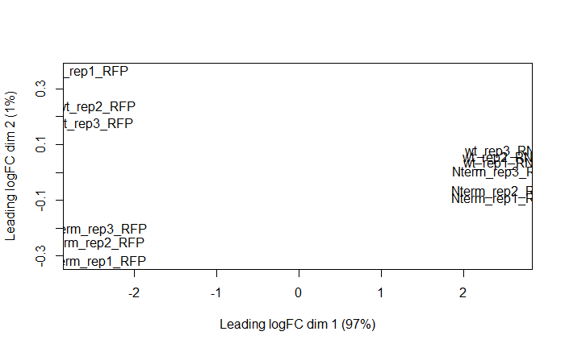

```r
# Set TE
data_all_te <- data_all

# plot MDS -- not very informative since of course the 1st PC is RNA vs RPF

lcpm_all = cpm(data_all, log=TRUE)
plotMDS(lcpm, labels=rownames(data_all$samples))
```

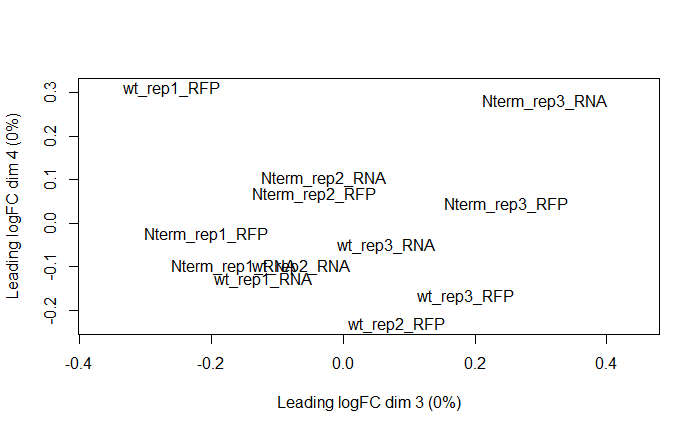

```r
plotMDS(lcpm, labels=rownames(data_all$samples), dim.plot=c(3,4))
```

```r
# displaying again for easy reference in constructing design_all matrix
data_all$samples
```

|  | group | lib.size | norm.factors | genotype | rep | RFP_or_RNA | grouping |
| --- | --- | --- | --- | --- | --- | --- | --- |
| wt_rep1_RFP | wt_RFP | 3835623 | 0.9767549 | wt | 1 | RFP | wt_RFP |
| wt_rep2_RFP | wt_RFP | 5250802 | 1.0021188 | wt | 2 | RFP | wt_RFP |
| wt_rep3_RFP | wt_RFP | 6607444 | 1.0070031 | wt | 3 | RFP | wt_RFP |
| Nterm_rep1_RFP | Nterm_RFP | 5913918 | 0.9768204 | Nterm | 1 | RFP | Nterm_RFP |
| Nterm_rep2_RFP | Nterm_RFP | 6286487 | 0.9967747 | Nterm | 2 | RFP | Nterm_RFP |
| Nterm_rep3_RFP | Nterm_RFP | 11178932 | 1.0419639 | Nterm | 3 | RFP | Nterm_RFP |
| wt_rep1_RNA | wt_RNA | 9889279 | 1.0006494 | wt | 1 | RNA | wt_RNA |
| Nterm_rep2_RNA | Nterm_RNA | 7225510 | 1.0027832 | Nterm | 2 | RNA | Nterm_RNA |
| wt_rep2_RNA | wt_RNA | 9146369 | 1.0153811 | wt | 2 | RNA | wt_RNA |
| wt_rep3_RNA | wt_RNA | 6998340 | 0.9882123 | wt | 3 | RNA | wt_RNA |

[output cut: 2 more lines]

```r
# our goal here is very similar to the example in the edgeR User's guide in section 3.5,
# 'Comparisons both between and within subjects'. The analogies are:
# Healthy/Disease1/Disease2 ~ S27>S27L, S27L>S27, and Unedited
# each patient ~ each replicate (note that in the example, they re-number their patients
# such that they have a patient #1, #2, and #3 in each disease)
# Treatment (hormone or none) (w/ a pair of treated/untreated samples for each patient) ~ RPF vs RNA

# In the example they don't include the '0' so it's just ~Disease; I think it's more
# intuitive to include the 0 so it's explicitly clear what baseline is being subtracted
# however this only seems to solve this for the line variable, not lane or fraction...
#

# line = factor(data_all$samples$genotype, levels=c('wt', 'Nterm'))
# fraction = factor(data_all$samples$RFP_or_RNA, levels=c('RNA', 'RFP'))
#
# design_all = model.matrix(~0+line+fraction:line, data=data_all$samples)
# colnames(design_all) = gsub(':', '_', colnames(design_all))
# design_all

# make contrasts
# diff_te = makeContrasts(lineNterm_fractionRFP-linewt_fractionRFP,
#                         levels=colnames(design_all))
#
# diff_te

line = factor(data_all$samples$genotype, levels=c('wt', 'Nterm'))
fraction = factor(data_all$samples$RFP_or_RNA, levels=c('RNA', 'RFP'))

design_all = model.matrix(~0+line:fraction, data=data_all$samples)
colnames(design_all) = gsub(':', '_', colnames(design_all))
design_all
```

```
               linewt_fractionRNA lineNterm_fractionRNA linewt_fractionRFP lineNterm_fractionRFP
wt_rep1_RFP                     0                     0                  1                     0
wt_rep2_RFP                     0                     0                  1                     0
wt_rep3_RFP                     0                     0                  1                     0
Nterm_rep1_RFP                  0                     0                  0                     1
Nterm_rep2_RFP                  0                     0                  0                     1
Nterm_rep3_RFP                  0                     0                  0                     1
wt_rep1_RNA                     1                     0                  0                     0
Nterm_rep2_RNA                  0                     1                  0                     0
wt_rep2_RNA                     1                     0                  0                     0
wt_rep3_RNA                     1                     0                  0                     0
Nterm_rep1_RNA                  0                     1                  0                     0
Nterm_rep3_RNA                  0                     1                  0                     0
attr(,"assign")
[1] 1 1 1 1
attr(,"contrasts")
attr(,"contrasts")$line
[1] "contr.treatment"

attr(,"contrasts")$fraction
[1] "contr.treatment"
```

```r
diff_te = makeContrasts(
    Nterm_TE_vs_wt_TE = (lineNterm_fractionRFP-lineNterm_fractionRNA)-(linewt_fractionRFP-linewt_fractionRNA),
                         levels=colnames(design_all))
diff_te
```

```
                       Contrasts
Levels                  Nterm_TE_vs_wt_TE
  linewt_fractionRNA                    1
  lineNterm_fractionRNA                -1
  linewt_fractionRFP                   -1
  lineNterm_fractionRFP                 1
```

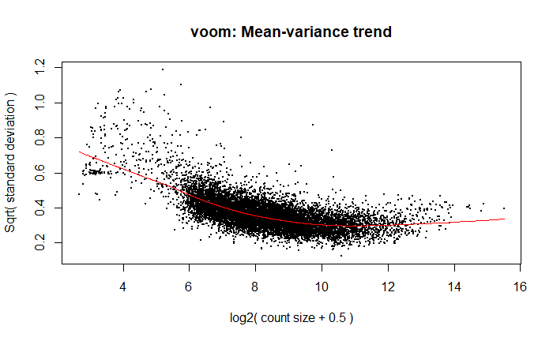

```r
# perform voom

v_te = voom(data_all, design_all, plot=TRUE)
```

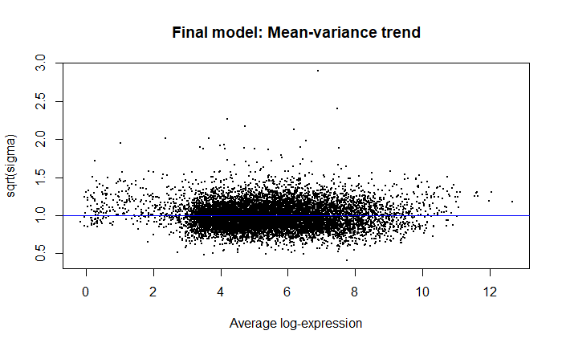

```r
# note that the v_te$E matrix is pretty close to a log2(CPM + something)
# (online documentation calls this a 'normalized counts' matrix)
# I checked this by manually dividing the raw values in data_all$counts by data_all$samples$lib.size
# and taking log2 -- the results aren't identical to v_te$E but at least for the first 4x4 entries
# (which are all in the 2^5 to 2^8 range for CPM) they are within 0.01 (in log space)

v_te_fit = lmFit(v_te, design_all)
v_te_fit = contrasts.fit(v_te_fit, contrasts=diff_te)
e_te_fit = eBayes(v_te_fit)
plotSA(e_te_fit, main="Final model: Mean-variance trend")
```

```r
dt_te = decideTests(e_te_fit, p.value=0.1)
summary(dt_te)
```

```
       Nterm_TE_vs_wt_TE
Down                   1
NotSig              9902
Up                     3
```

```r
head(e_te_fit)
```

```
An object of class "MArrayLM"
$coefficients
                         Contrasts
                          Nterm_TE_vs_wt_TE
  SLC41A2_ENST00000258538       -0.20200396
  PARN_ENST00000437198          -0.07912184
  KLHL36_ENST00000564996         0.21500780
  TSTD2_ENST00000341170          0.01697008
  PLXNA1_ENST00000393409        -0.06807762
  PTPN2_ENST00000309660         -0.02395191

$stdev.unscaled
                         Contrasts
                          Nterm_TE_vs_wt_TE
  SLC41A2_ENST00000258538         0.2712710
  PARN_ENST00000437198            0.1418079
  KLHL36_ENST00000564996          0.2119741
  TSTD2_ENST00000341170           0.1253668
  PLXNA1_ENST00000393409          0.1037219
  PTPN2_ENST00000309660           0.1581774

$sigma
[1] 1.1273336 0.9078217 0.8599556 0.7455836 0.7880364 0.7681290

$df.residual
[1] 8 8 8 8 8 8

$cov.coefficients
                   Contrasts
Contrasts           Nterm_TE_vs_wt_TE
  Nterm_TE_vs_wt_TE          1.333333

$pivot
[1] 1 2 3 4

$rank
[1] 4

$Amean
SLC41A2_ENST00000258538    PARN_ENST00000437198  KLHL36_ENST00000564996   TSTD2_ENST00000341170
```

[output cut: 62 more lines]

```
$lods
                         Contrasts
                          Nterm_TE_vs_wt_TE
  SLC41A2_ENST00000258538         -4.803783
  PARN_ENST00000437198            -5.212023
  KLHL36_ENST00000564996          -4.711491
  TSTD2_ENST00000341170           -5.436818
  PLXNA1_ENST00000393409          -5.378092
  PTPN2_ENST00000309660           -5.254497

$F
[1] 0.50598349 0.33672762 1.15333249 0.02230202 0.50886509 0.02747052

$F.p.value
[1] 0.4847651 0.5679429 0.2951241 0.8827215 0.4835389 0.8699562
```

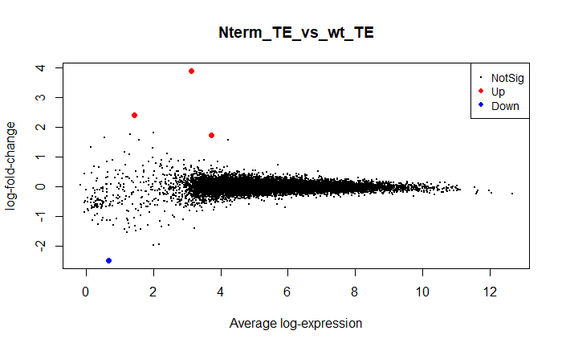

```r
#output_file <- "wtRFP-NtermRFP_plotMD_output.pdf"
#pdf(output_file)
plotMD(e_te_fit, column=1, status=dt_te[,1], main=colnames(e_te_fit)[1])
```

```r
#dev.off()
```

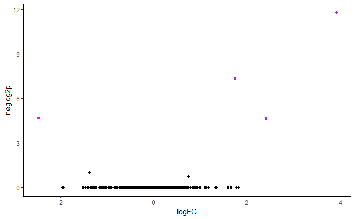

```r
# volcano plot
top_te_genes = topTable(e_te_fit, coef=1, number=sum(keep_all_cpm), sort.by='p')

top_te_genes$neglog2p = -log(top_te_genes$adj.P.Val, 2)
top_te_genes$plot_fill = rep('black', nrow(top_te_genes))
top_te_genes[top_te_genes$logFC > 0.25 & top_te_genes$adj.P.Val < 0.05,'plot_fill'] = 'purple'
top_te_genes[top_te_genes$logFC < -0.25 & top_te_genes$adj.P.Val < 0.05,'plot_fill'] = 'magenta'

pal = c('black', 'magenta', 'purple')

top_te_genes$plot_fill = factor(top_te_genes$plot_fill, levels = pal)

options(repr.plot.width=4, repr.plot.height=4)

ggplot(data=top_te_genes,
       aes(x=logFC, y=neglog2p, color=plot_fill)) +
geom_point() +
scale_color_manual(values=pal) +
theme_classic() +
theme(legend.position='none')
```

```r
head(top_te_genes)
```

|  | logFC | AveExpr | t | P.Value | adj.P.Val | B | neglog2p | plot_fill |
| --- | --- | --- | --- | --- | --- | --- | --- | --- |
| ZNF562_ENST00000453372 | 3.9045898 | 3.1335021 | 8.575326 | 2.813140e-08 | 0.0002786696 | -0.8818777 | 11.809157 | purple |
| PCDHGB4_ENST00000519479 | 1.7348132 | 3.7214409 | 6.730541 | 1.212066e-06 | 0.0060033646 | 0.1362817 | 7.380013 | purple |
| TBCE_ENST00000645655 | -2.4777956 | 0.6716719 | -5.714021 | 1.165362e-05 | 0.0384802532 | -2.8105201 | 4.699738 | magenta |
| SNURF_ENST00000577949 | 2.4019064 | 1.4293464 | 5.575521 | 1.601151e-05 | 0.0396525162 | -2.8031725 | 4.656444 | purple |
| LLPH_ENST00000266604 | -1.3841856 | 3.2137455 | -4.407186 | 2.490459e-04 | 0.4934096844 | -2.3427575 | 1.019142 | black |
| SEM1_ENST00000248566 | 0.7350453 | 5.7131645 | 4.250247 | 3.619823e-04 | 0.5976326973 | -0.3281625 | 0.742669 | black |

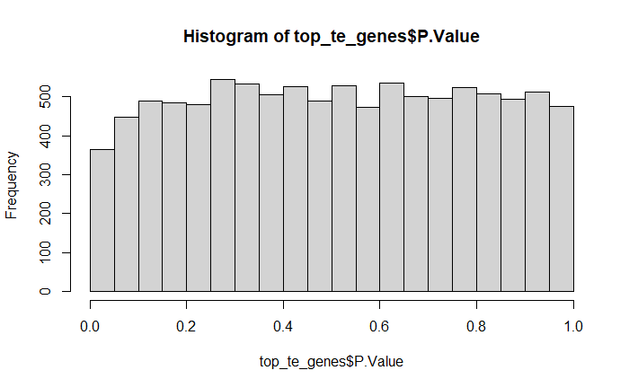

```r
# check distribution of p-values
hist(top_te_genes$P.Value)
```

```r
# check correlation between samples
cor(v_te$E)
```

```
               wt_rep1_RFP wt_rep2_RFP wt_rep3_RFP Nterm_rep1_RFP Nterm_rep2_RFP Nterm_rep3_RFP wt_rep1_RNA
wt_rep1_RFP      1.0000000   0.9913609   0.9904880      0.9886550      0.9904643      0.9869062   0.6749702
wt_rep2_RFP      0.9913609   1.0000000   0.9933977      0.9892523      0.9914642      0.9897673   0.6677206
wt_rep3_RFP      0.9904880   0.9933977   1.0000000      0.9892936      0.9915713      0.9923691   0.6638102
Nterm_rep1_RFP   0.9886550   0.9892523   0.9892936      1.0000000      0.9923757      0.9895566   0.6710494
Nterm_rep2_RFP   0.9904643   0.9914642   0.9915713      0.9923757      1.0000000      0.9913495   0.6611282
Nterm_rep3_RFP   0.9869062   0.9897673   0.9923691      0.9895566      0.9913495      1.0000000   0.6484319
wt_rep1_RNA      0.6749702   0.6677206   0.6638102      0.6710494      0.6611282      0.6484319   1.0000000
Nterm_rep2_RNA   0.6773521   0.6703527   0.6656985      0.6725056      0.6644075      0.6519405   0.9915559
wt_rep2_RNA      0.6755558   0.6689113   0.6651413      0.6708682      0.6617281      0.6494338   0.9950055
wt_rep3_RNA      0.6699757   0.6636929   0.6610717      0.6662806      0.6564281      0.6456697   0.9937366
Nterm_rep1_RNA   0.6691723   0.6623593   0.6591179      0.6689531      0.6582518      0.6449112   0.9936267
Nterm_rep3_RNA   0.6690599   0.6622847   0.6600195      0.6634996      0.6555175      0.6471365   0.9889237
               Nterm_rep2_RNA wt_rep2_RNA wt_rep3_RNA Nterm_rep1_RNA Nterm_rep3_RNA
wt_rep1_RFP         0.6773521   0.6755558   0.6699757      0.6691723      0.6690599
wt_rep2_RFP         0.6703527   0.6689113   0.6636929      0.6623593      0.6622847
wt_rep3_RFP         0.6656985   0.6651413   0.6610717      0.6591179      0.6600195
Nterm_rep1_RFP      0.6725056   0.6708682   0.6662806      0.6689531      0.6634996
Nterm_rep2_RFP      0.6644075   0.6617281   0.6564281      0.6582518      0.6555175
Nterm_rep3_RFP      0.6519405   0.6494338   0.6456697      0.6449112      0.6471365
wt_rep1_RNA         0.9915559   0.9950055   0.9937366      0.9936267      0.9889237
Nterm_rep2_RNA      1.0000000   0.9916304   0.9898374      0.9883823      0.9906530
wt_rep2_RNA         0.9916304   1.0000000   0.9936492      0.9921871      0.9908144
wt_rep3_RNA         0.9898374   0.9936492   1.0000000      0.9915575      0.9907759
Nterm_rep1_RNA      0.9883823   0.9921871   0.9915575      1.0000000      0.9856734
Nterm_rep3_RNA      0.9906530   0.9908144   0.9907759      0.9856734      1.0000000
```

```r
# shortcut for finding the rowname corresponding to a gene
rownames(v_te$E)[grep('ELMO1', rownames(v_te$E))]
```

```
[1] "ELMO1_ENST00000310758"
```

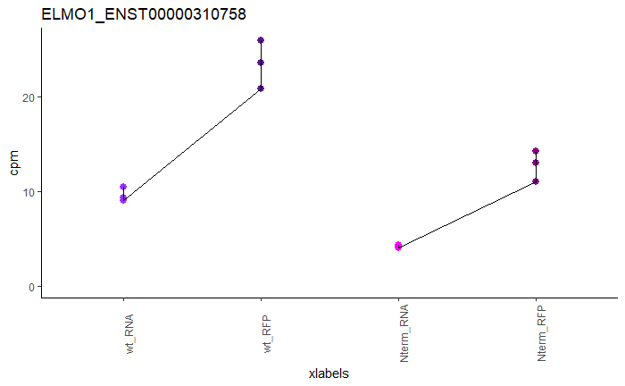

```r
library(repr)
options(repr.plot.width=4, repr.plot.height=4)

goi = 'ELMO1_ENST00000310758'

# goi = 'LLPH_ENST00000266604'
norm_counts = 2^v_te$E[goi,]

palette = c('purple1', 'purple4', 'magenta', 'magenta4', 'gray50', 'gray20')

df = data.frame(sample = names(norm_counts), cpm = norm_counts)
df = separate(df, sample, c("genotype", "replicate", "fraction"))
df$lines = factor(df$genotype, levels=c('wt', 'Nterm'))
df$xlabels = factor(paste(df$genotype, df$fraction, sep="_"),
                    levels=c('wt_RNA',
                             'wt_RFP',
                             'Nterm_RNA',
                             'Nterm_RFP'))

p1 = ggplot(df, aes(x=xlabels, y=cpm))
p1 + geom_point(aes(color = xlabels), size=2.5) + geom_path(group=df$genotype) + ggtitle(goi) + theme_classic() + theme(legend.position = 'none', axis.text.x = element_text(angle = 90)) + expand_limits(y=0) + scale_color_manual(values = palette)
```

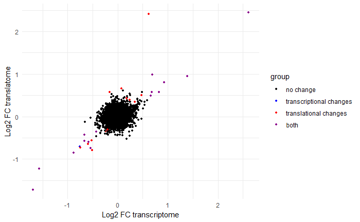

```r
# Scatter plot of rna and rfp sig. genes

rfp_fc_sig <- tibble("gene" =  row.names(e_rfp_fit$coefficients),
                     "RFP_Nterm-wt_fc" = e_rfp_fit$coefficients[,1],
                     "RFP_Nterm-wt_sig" = as.vector(dt_rfp))
rna_fc_sig <- tibble("gene" = row.names(e_rna_fit$coefficients),
                     "RNA_Nterm-wt_fc" = e_rna_fit$coefficients[,1],
                     "RNA_Nterm-wt_sig" = as.vector(dt_rna))
all_fc_sig <- full_join(rfp_fc_sig, rna_fc_sig, by = "gene") %>%
  separate(gene, into = c("gene_name", "transcriptID"), sep = "_")

# 0 is not sig, 1 is only sig in rna, 2 is only sig in rfp, 3 is sig in both.
all_fc_sig$group <- factor(
  1 * (!is.na (all_fc_sig$`RNA_Nterm-wt_sig`) & all_fc_sig$`RNA_Nterm-wt_sig` != 0) +
    2 * (!is.na (all_fc_sig$`RFP_Nterm-wt_sig`) & all_fc_sig$`RFP_Nterm-wt_sig` != 0)
)

palette = c('black', 'blue', 'red', 'magenta4')
legends = c('no change', 'transcriptional changes', 'translational changes', 'both')

ggplot(all_fc_sig, aes(x=`RNA_Nterm-wt_fc`, y=`RFP_Nterm-wt_fc`)) +
  geom_point(aes(color = group), size = 1) +
  scale_color_manual(
    values = palette,
    labels = legends) +
  theme_minimal() +
  # xlim(-2, 2) + ylim (-2, 2) +
  xlab("Log2 FC transcriptome") + ylab("Log2 FC translatome")
```

```r
# ggsave("rna_rfp_sig_genes_d5.pdf", width=8, height=7)
```

```r
translation_up <- all_fc_sig %>% filter(group == 2 & `RFP_Nterm-wt_sig` == 1) %>% select(gene_name)
translation_down <- all_fc_sig %>% filter(group == 2 & `RFP_Nterm-wt_sig` == -1) %>% select(gene_name)
both_down <- all_fc_sig %>% filter(group == 3 & `RFP_Nterm-wt_sig` == -1) %>% select(gene_name)
all_genes <- all_fc_sig %>% select(gene_name)

# write.csv(translation_up, file = "./output/hiND5_translation_up.csv", row.names = FALSE)
# write.csv(translation_down, file = "./output/hiND5_translation_down.csv", row.names = FALSE)
# write.csv(both_down, file = "./output/hiND5_both_down.csv", row.names = FALSE)
# write.csv(all_genes, file = "./output/hiND5_all_genes.csv", row.names = FALSE)
```

I am using riboWaltz to process this data. I create annotation_dt using the human primary assembly basic annotation that I used to align my RFP data with STAR. I’m also loading the data and convert them into list.

```r
annotation_dt=create_annotation(gtfpath = "ref/gencode.v43.primary_assembly.basic.annotation.gtf")
bam_list <- bamtolist("data/20230722_hiND14", annotation = annotation_dt, refseq_sep = "|")
```

Call for psite, flanking = 6, extremity = “auto” Use default recommended settings: Also save the offsets per sample in a text file

```r
offsets <- psite(data = bam_list)
samples <- unique(offsets$sample)
for (i in 1:length(samples)) {
  sam_offs <- subset(offsets, sample == samples[i],
                    select = c("length", "corrected_offset_from_3"))
  colnames(sam_offs) <- c("length", "p_offset")
  write.table(sam_offs, paste("output/20230722_hiND14/", samples[i], "_p-site-offsets.tsv", sep=""),
              sep = "\t", row.names = FALSE)
}
```

Get the main table of reads with psite information. Tried saving each psite list for each sample, but the filesize is way too big. Don’t do it.

```r
reads_psite_list <- psite_info(bam_list, offsets,
                               fastapath = "ref/GRCh38.primary_assembly.genome.fa",
                               fasta_genome = TRUE, refseq_sep = " ",
                               gtfpath = "ref/gencode.v43.primary_assembly.basic.annotation.gtf")
```

Given that I’m interested to look at a-site codon usage, I’m filtering out all reads mapped to 3’utr, and those mapped right before the stop codon. A lot of those reads threw an error unfortunately. The package is being updated

```r
for(n in names(reads_psite_list)) {
  reads_psite_list[[n]] <- reads_psite_list[[n]][!which(reads_psite_list[[n]]$psite_region == "3utr")]
  reads_psite_list[[n]] <- reads_psite_list[[n]][!which(reads_psite_list[[n]]$psite_region == "cds" & reads_psite_list[[n]]$end3 < reads_psite_list[[n]]$psite + 3)]
  reads_psite_list[[n]] <- reads_psite_list[[n]][!is.na(reads_psite_list[[n]]$psite_region)]
}
```

Checking for codon usage:

p-site

```r
fasta_path = "ref/GRCh38.primary_assembly.genome.fa"
gtf_path = "ref/gencode.v43.primary_assembly.basic.annotation.gtf"
codon_table <- read.table(file = "codon_table.tsv", sep = "\t", header=TRUE)

codon_usage_psite_all <- codon_table
codon_rank_psite_all <- codon_table

for(n in names(reads_psite_list)) {
  codon_usage <- codon_usage_psite(reads_psite_list, annotation = annotation_dt,
                                   sample = n, fastapath = fasta_path, gtfpath = gtf_path,
                                   fasta_genome = TRUE, refseq_sep = " ", site = "psite")
  codon_usage_psite_all <- left_join(codon_usage_psite_all,
                                     codon_usage$dt[, .(codon, normalized_value)], by="codon")
  normalized_value_index <- which(colnames(codon_usage_psite_all) == "normalized_value")
  colnames(codon_usage_psite_all)[normalized_value_index] <- n
  codon_rank_psite_all[[n]] <- rank(codon_usage_psite_all[[n]])
}

codon_usage_psite_all$wt_RFP_ave = rowMeans(
  codon_usage_psite_all[, c("hiND14_wt_rep_1_RFP", "hiND14_wt_rep_2_RFP", "hiND14_wt_rep_3_RFP")])
codon_usage_psite_all$Nterm_RFP_ave = rowMeans(
  codon_usage_psite_all[, c("hiND14_Nterm_rep_1_RFP", "hiND14_Nterm_rep_2_RFP", "hiND14_Nterm_rep_3_RFP")])
codon_usage_psite_all <- codon_usage_psite_all %>%
  mutate(wt_RFP_ave_plot = wt_RFP_ave/max(codon_usage_psite_all$wt_RFP_ave),
         Nterm_RFP_ave_plot = Nterm_RFP_ave/max(codon_usage_psite_all$Nterm_RFP_ave))
```

Trying to do wilcoxon rank-sum test:

```r
wt <- c(codon_rank_psite_all$wt_RFP_1, codon_rank_psite_all$wt_RFP_2, codon_rank_psite_all$wt_RFP_3)
Nterm <- c(codon_rank_psite_all$Nterm_RFP_1, codon_rank_psite_all$Nterm_RFP_2, codon_rank_psite_all$Nterm_RFP_3)
wilcox.test(wt, Nterm)
```

a-site.

```r
fasta_path = "data/Try2/GRCh38.primary_assembly.genome.fa"
gtf_path = "data/Try2/gencode.v43.primary_assembly.basic.annotation.gtf"
codon_table <- read.table(file = "codon_table.tsv", sep = "\t", header=TRUE)

codon_usage_asite_all <- codon_table

for(n in names(reads_psite_list)) {
  codon_usage <- codon_usage_psite(reads_psite_list, annotation = annotation_dt,
                                   sample = n, fastapath = fasta_path, gtfpath = gtf_path,
                                   fasta_genome = TRUE, refseq_sep = " ", site = "asite")
  codon_usage_asite_all <- left_join(codon_usage_asite_all,
                                     codon_usage$dt[, .(codon, normalized_value)], by="codon")
  normalized_value_index <- which(colnames(codon_usage_asite_all) == "normalized_value")
  colnames(codon_usage_asite_all)[normalized_value_index] <- n
}

codon_usage_asite_all$wt_RFP_ave = rowMeans(
  codon_usage_asite_all[, c("hiND14_wt_rep_1_RFP", "hiND14_wt_rep_2_RFP", "hiND14_wt_rep_3_RFP")])
codon_usage_asite_all$Nterm_RFP_ave = rowMeans(
  codon_usage_asite_all[, c("hiND14_Nterm_rep_1_RFP", "hiND14_Nterm_rep_2_RFP", "hiND14_Nterm_rep_3_RFP")])
codon_usage_asite_all <- codon_usage_asite_all %>%
  mutate(wt_RFP_ave_plot = wt_RFP_ave/max(codon_usage_asite_all$wt_RFP_ave),
         Nterm_RFP_ave_plot = Nterm_RFP_ave/max(codon_usage_asite_all$Nterm_RFP_ave))
```

Do a scatter plot with linear model fitting

```r
bs <- 25
label_number <- 5
# plot_df <- codon_usage_psite_all
plot_df <- codon_usage_asite_all
setDT(plot_df)
plot_df <- plot_df[order(wt_RFP_ave_plot)][, `:=`(codon, factor(codon, levels = codon))]

correlation <- round(cor(plot_df$wt_RFP_ave_plot,
                         plot_df$Nterm_RFP_ave_plot), 3)

fit <- lm(plot_df$Nterm_RFP_ave_plot ~ plot_df$wt_RFP_ave_plot)
outlier_tab <- data.table(predict.lm(fit, interval = "confidence", level = 0.95))[, `:=`(codon, plot_df$codon)][, `:=`(Nterm_RFP_ave_plot, plot_df$Nterm_RFP_ave_plot)][Nterm_RFP_ave_plot < lwr | Nterm_RFP_ave_plot > upr]
outlier_cod <- as.character(outlier_tab[, `:=`(max_dist, min(abs(Nterm_RFP_ave_plot - lwr),
                                                             abs(Nterm_RFP_ave_plot - upr))),
                                        by = 1:nrow(outlier_tab)][order(-max_dist)][1:label_number, codon])
lab_table <- plot_df[, `:=`(codon_out, "")][as.character(codon) %in% outlier_cod, `:=`(codon_out, codon)
                                               ][, `:=`(aa_out, "")][codon_out != "", `:=`(aa_out, aa)]

ggplot(plot_df, aes(x = wt_RFP_ave_plot, y=Nterm_RFP_ave_plot)) +
  geom_smooth(method = "lm", se = TRUE, color = "gray80", fill = "gray80", linetype= 1,
              formula = y ~ x, level = 0.95, fullrange = TRUE) +
  geom_point(alpha = 0.5, size = bs* 0.14) +
  theme_bw(base_size = bs) +
  theme(legend.position = "top", legend.margin = margin(0,0,0,0),
        legend.box.margin = margin(5,0,-15,0)) +
  theme(legend.text = element_text(margin = margin(l = -12, unit = "pt"))) +
  theme(panel.grid.minor.y = element_blank(), panel.grid.minor.x = element_blank()) +
  scale_x_continuous(name = "LLPH wt", limits = c(-0.3, 1.3),
                     breaks = c(0, 0.25, 0.5, 0.75, 1), expand = c(0, 0)) +
  scale_y_continuous(name = "LLPH Nterm", limits = c(-0.3, 1.3),
                     breaks = c(0, 0.25, 0.5, 0.75, 1), expand = c(0, 0)) +
  coord_cartesian(xlim = c(-0.05, 1.05), ylim = c(-0.05, 1.05)) +
  annotate("text", x = 1, y = 0, label = paste0("R=", correlation),
           vjust = -0.2, size = bs * 0.2, hjust = 1, color = "black") +
  geom_abline(intercept = 0, slope = 1, color = "red") +
  ggrepel::geom_text_repel(data = lab_table, aes(label = codon_out), show.legend = F)

#ggsave("Nterm_vs_wt_codon_psite.pdf")
#ggsave("Nterm_vs_wt_codon_asite.pdf")
```

```r
bs <- 25
label_number <- 10
# plot_df <- codon_usage_psite_all
plot_df <- codon_usage_asite_all
setDT(plot_df)
plot_df <- plot_df[order(hiND14_Nterm_rep_1_RFP)][, `:=`(codon, factor(codon, levels = codon))]

correlation <- round(cor(plot_df$hiND14_Nterm_rep_1_RFP,
                         plot_df$hiND14_Nterm_rep_2_RFP), 3)

fit <- lm(plot_df$hiND14_Nterm_rep_2_RFP ~ plot_df$hiND14_Nterm_rep_1_RFP)
outlier_tab <- data.table(predict.lm(fit, interval = "confidence", level = 0.95))[, `:=`(codon, plot_df$codon)][, `:=`(hiND14_Nterm_rep_2_RFP, plot_df$hiND14_Nterm_rep_2_RFP)][hiND14_Nterm_rep_2_RFP < lwr | hiND14_Nterm_rep_2_RFP > upr]
outlier_cod <- as.character(outlier_tab[, `:=`(max_dist, min(abs(hiND14_Nterm_rep_2_RFP - lwr),
                                                             abs(hiND14_Nterm_rep_2_RFP - upr))),
                                        by = 1:nrow(outlier_tab)][order(-max_dist)][1:label_number, codon])
lab_table <- plot_df[, `:=`(codon_out, "")][as.character(codon) %in% outlier_cod, `:=`(codon_out, codon)
                                               ][, `:=`(aa_out, "")][codon_out != "", `:=`(aa_out, aa)]

ggplot(plot_df, aes(x = hiND14_Nterm_rep_1_RFP, y=hiND14_Nterm_rep_2_RFP)) +
  geom_smooth(method = "lm", se = TRUE, color = "gray80", fill = "gray80", linetype= 1,
              formula = y ~ x, level = 0.95, fullrange = TRUE) +
  geom_point(alpha = 0.5, size = bs* 0.14) +
  theme_bw(base_size = bs) +
  theme(legend.position = "top", legend.margin = margin(0,0,0,0),
        legend.box.margin = margin(5,0,-15,0)) +
  theme(legend.text = element_text(margin = margin(l = -12, unit = "pt"))) +
  theme(panel.grid.minor.y = element_blank(), panel.grid.minor.x = element_blank()) +
  annotate("text", x = 1, y = 0, label = paste0("R=", correlation),
           vjust = -0.2, size = bs * 0.2, hjust = 1, color = "black") +
  geom_abline(intercept = 0, slope = 1, color = "red") +
  ggrepel::geom_text_repel(data = lab_table, aes(label = codon_out), show.legend = F)
```

Check how the reads are distributed for a given transcript.

```r
# To plot read counts against position given a particular gene in a given sample:
transcript_id = "ENST00000239938.5"
reads_psite_sample = "hiND14_Nterm_rep_3_RFP"

# Get the read counts for a given p-siste position of a specific transcript in a given sample.
psite_counts <- reads_psite_list[[reads_psite_sample]][
  reads_psite_list[[reads_psite_sample]]$transcript == transcript_id ,
  ]$psite

# Convert counts table to data frame, change the column names.
counts <- as.data.frame(table(psite_counts))
colnames(counts) <- c("Position", "ReadCount")

# Generate a sequence of numbers from 0 or min. number to the max. number.
counts$Position <- as.numeric(as.character(counts$Position))
number_range <- seq(pmin(min(counts$Position), 0), max(counts$Position))

# Complete the data frame with missing numbers and set their counts to 0.
# Normalize ReadCount with the size of the library.
nrow_reads = nrow(reads_psite_list[[reads_psite_sample]])
counts_complete <- counts %>%
  complete(Position = number_range) %>%
  replace_na(list(ReadCount = 0)) %>%
  mutate(ReadCount = ReadCount / nrow_reads * 1000000)

# Parse information about genotype, rfp/rna, and rep number.
genotype <- ""
if (grepl("wt", reads_psite_sample)) genotype = "wt" else genotype = "Nterm"
rfp_or_rna  <- ""
if (grepl("RFP", reads_psite_sample)) rfp_or_rna = "RFP" else rfp_or_rna = "RNA"
rep_number <- ""
if (grepl("rep_", reads_psite_sample)) {
  # Extract the number immediately following "rep"
  rep_number <- str_extract(reads_psite_sample, "(?<=rep_)\\d+")
  }
# Combine the genotype, rfp/rna, and rep number information into a new sample name.
sample_name = paste(genotype, rfp_or_rna, rep_number, sep = "_")

p <- ggplot(counts_complete, aes(x = Position, y = ReadCount)) + geom_line() +
  labs(x = "position", y = "read count", title = paste(transcript_id, " read counts in ", sample_name), sep = "") +
  theme_bw() +
  theme(panel.grid.minor = element_blank()) +
  coord_cartesian(ylim = c(0,0.15), xlim= c(0,2500))

#Limit max position to 5000 for ZNF562
#Limit max position to 500 for LLPH
#Limit max position to 350 for SNURF
#Limit max position to 300 for SEM1

ggsave(filename = paste("output/20230722_hiND14/", transcript_id, "_", sample_name, ".png", sep =""), plot = p, width = 8, height = 4, dpi = 600)
```

```r
sample_list <- list("wt_avg" = c("hiND14_wt_rep_1_RFP", "hiND14_wt_rep_2_RFP", "hiND14_wt_rep_3_RFP"),
                    "Nterm_avg" = c("hiND14_Nterm_rep_1_RFP", "hiND14_Nterm_rep_2_RFP", "hiND14_Nterm_rep_3_RFP"))

length_dist_dodged <- rlength_distr(bam_list,
                                    sample = sample_list, cl = 99,
                                    multisamples = "average",
                                    plot_style = "dodged",
                                    colour = c("dodgerblue", "gray70"))
length_dist_dodged[["plot"]]
```

```r
example_frames_stratified <- frame_psite_length(reads_psite_list, sample = "hiND14_Nterm_rep_3_RFP",
                                                region = "all", cl = 90)
example_frames_stratified[["plot"]]
```

Check for metaprofile psite as a representative of trinucleotide periodicity across all start codons.

```r
sample_list <- list("wt_avg" = c("hiND14_wt_rep_1_RFP", "hiND14_wt_rep_2_RFP", "hiND14_wt_rep_3_RFP"),
                    "Nterm_avg" = c("hiND14_Nterm_rep_1_RFP", "hiND14_Nterm_rep_2_RFP", "hiND14_Nterm_rep_3_RFP"))
example_metaprofile_overlaid <- metaprofile_psite(reads_psite_list, annotation_dt,
                                                  sample = sample_list,
                                                  multisamples = "average", plot_style = "overlaid",
                                                  utr5l = 20, cdsl = 40, utr3l = 20,
                                                  frequency = TRUE, plot_title = "transcript",
                                                  colour = c("aquamarine4", "gray70"))
example_metaprofile_overlaid[["plot"]]
```